# Random Variables

Raúl López

2024-03-06

# Introduction

- Random variables are numeric outcomes resulting from random processes.
- Statistical inference offers a framework for quantifying uncertainty due to randomness.

```r
set.seed(1)
# define random variable x to be 1 if blue, 0 otherwise
beads <- rep(c("red", "blue"), times = c(2, 3))
x <- ifelse(sample(beads, 1) == "blue", 1, 0)
print(x)
```

```
## [1] 0
```

# Sampling Models

- A sampling model models the random behavior of a process as the sampling of draws from an urn.
- The probability distribution of a random variable is the probability of the observed value falling in any given interval.
- We can define a CDF F(a)=Pr(S<=a) to answer questions related to the probability of S being in any interval.
- The average of many draws of a random variable is called its expected value.
- The standard deviation of many draws of a random variable is called its standard error.

We use sampling model to run a Monte Carlo simulation and use the results to estimate the probability of an event. In this example, we have a casino with 1000 players of roulette each day. We have 38 pockets (18 red, 18 black and 2 green). The player bet 1$ and the events are:

- red: the casino losses 1$
- black and green: the casino wins 1$

The model of this random variable is:

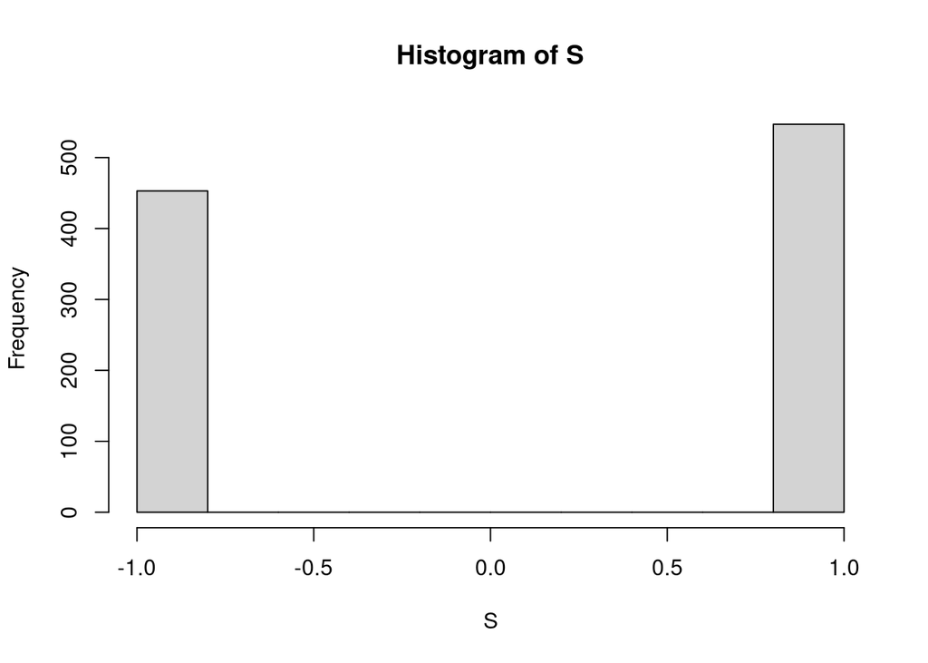

```r
red <- 18
black <- 18
green <- 2
n <- 1000

S <- sample(c(1,-1), # options are +1 and -1
       n, # players are 1000
       replace = TRUE,
       prob = c(20/38, # probability of win
                18/38)) # probability of lose
hist(S) # distribution
```

```r
sum(S) # total gains
```

```
## [1] 94
```

```r
mean(S) # mean gain
```

```
## [1] 0.094
```

We use the sampling model to run a Monte Carlo simulation

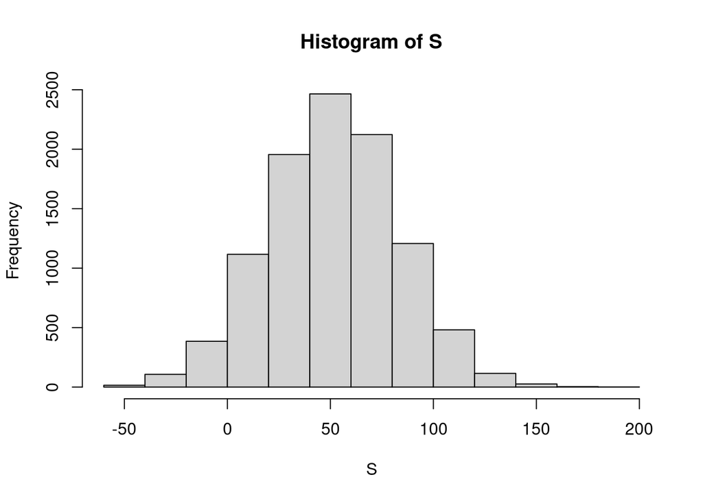

```r
n <- 1000    # number of roulette players
B <- 10000    # number of Monte Carlo experiments
S <- replicate(B, {
    X <- sample(c(-1,1), n, replace = TRUE, prob = c(9/19, 10/19))    # simulate 1000 roulette spins
    sum(X)    # determine total profit
})

hist(S) # distribution of results
```

```r
mean(S) # mean results
```

```
## [1] 52.5392
```

```r
mean(S < 0)    # probability of the casino losing money
```

```
## [1] 0.0442
```

# Distributions versus Probability Distributions

- A random variable X has a probability distribution function F(a) that defines Pr(X<=a) over all values of a.
- Any list of numbers has a distribution. The probability distribution function of a random variable is defined mathematically and does not depend on a list of numbers.
- The results of a Monte Carlo simulation with a large enough number of observations will approximate the probability distribution of X.
- If a random variable is defined as draws from an urn:

The probability distribution function of the random variable is defined as the distribution of the list of values in the urn.

The expected value of the random variable is the average of values in the urn.

The standard error of one draw of the random variable is the standard deviation of the values of the urn.

- Capital letters denote random variables (X) and lowercase letters denote observed values (x).
- In the notation Pr(X=x), we are asking how frequently the random variable X is equal to the value x.

# Central Limit Theorem

- The Central Limit Theorem (CLT) says that the distribution of the sum of a random variable is approximated by a normal distribution.
- The expected value of a random variable, E[X] = u, is the average of the values in the urn. This represents the expectation of one draw.
- The standard error of one draw of a random variable is the standard deviation of the values in the urn.
- The expected value of the sum of draws is the number of draws times the expected value of the random variable.
- The standard error of the sum of independent draws of a random variable is the square root of the number of draws times the standard deviation of the urn.
- These equations apply to the case where there are only two outcomes, a and b with proportions p and 1-p respectively. The general principles above also apply to random variables with more than two outcomes.

Expected value of a random variable: E[X] = ap + b(1-p) Expected value of the sum of n draws of a random variable: n*E[X] Standard deviation of an urn with two values: sd(X) = |b-a|*sqrt(p(1-p)) Standard error of the sum of n draws of a random variable: sqrt(n) * sd(X)

# Exercises

1. An American roulette wheel has 18 red, 18 black, and 2 green pockets. Each red and black pocket is associated with a number from 1 to 36. The two remaining green slots feature “0” and “00”. Players place bets on which pocket they think a ball will land in after the wheel is spun. Players can bet on a specific number (0, 00, 1-36) or color (red, black, or green). What are the chances that the ball lands in a green pocket?

```r
green <- 2
black <- 18
red <- 18
green/(black+red+green)
```

```
## [1] 0.05263158
```

2. In American roulette, the payout for winning on green is $17. This means that if you bet $1 and it lands on green, you get $17 as a prize. Create a model to predict your winnings from betting on green one time.

```r
set.seed(1)

# The variables 'green', 'black', and 'red' contain the number of pockets for each color
green <- 2
black <- 18
red <- 18

p_green <- green/(black+red+green)
p_not_green <- 1 - p_green

prob = sample(c(-1,17), 1, prob = c(p_not_green,p_green), replace = TRUE)
print(prob)
```

```
## [1] -1
```

3. In American roulette, the payout for winning on green is $17. This means that if you bet $1 and it lands on green, you get $17 as a prize. In the previous exercise, you created a model to predict your winnings from betting on green. Now, compute the expected value of X, the random variable you generated previously.

```r
# The variables 'green', 'black', and 'red' contain the number of pockets for each color
green <- 2
black <- 18
red <- 18

p_green <- green/(black+red+green)
p_not_green <- 1 - p_green

X = 17*p_green + -1*(p_not_green)
X
```

```
## [1] -0.05263158
```

4. The standard error of a random variable tells us the difference between a random variable X and its expected value. You calculated a random variable X in exercise 2 and the expected value of that random variable in exercise 3. Now, compute the standard error of that random variable, which represents a single outcome after one spin of the roulette wheel.

```r
green <- 2
black <- 18
red <- 18

p_green <- green/(black+red+green)
p_not_green <- 1 - p_green

sdX <- abs(-1-17)*sqrt(p_green*p_not_green)
sdX
```

```
## [1] 4.019344
```

5. You modeled the outcome of a single spin of the roulette wheel,X, in exercise 2. Now create a random variable S that sums your winnings after betting on green 1,000 times.

```r
set.seed(1)

# The variables 'green', 'black', and 'red' contain the number of pockets for each color
green <- 2
black <- 18
red <- 18

p_green <- green/(black+red+green)
p_not_green <- 1 - p_green

n <- 1000
X <- sample(c(-1,17),n,replace = TRUE, prob = c(p_not_green, p_green))
S <- sum(X)
S
```

```
## [1] -10
```

6. In the previous exercise, you generated a vector of random outcomes,S, after betting on green 1,000 times. What is the expected value of S? What is the standard error?

```r
# The variables 'green', 'black', and 'red' contain the number of pockets for each color
green <- 2
black <- 18
red <- 18

p_green <- green/(black+red+green)
p_not_green <- 1 - p_green

X <- 17*p_green + -1*(p_not_green)
n <- 1000
n*X
```

```
## [1] -52.63158
```

```r
sdX <- abs(-1-17)*sqrt(p_green*p_not_green)
sqrt(n)*sdX
```

```
## [1] 127.1028
```

# Averages and Proportions

- Random variable times a constant

The expected value of a random variable multiplied by a constant is that constant times its original expected value The standard error of a random variable multiplied by a constant is that constant times its original standard error

E[aX] = a*mu SE[aX] = a*se

- Average of multiple draws of a random variable

The expected value of the average of multiple draws from an urn is the expected value of the urn (mu). The standard deviation of the average of multiple draws from an urn is the standard deviation of the urn divided by the square root of the number of draws (se/sqrt(n)).

- The sum of multiple draws of a random variable

The expected value of the sum of n draws of a random variable is n times its original expected value The standard error of the sum of n draws of random variable is sqrt(n) times its original standard error

- The sum of multiple different random variables

The expected value of the sum of different random variables is the sum of the individual expected values for each random variable The standard error of the sum of different random variables is the square root of the sum of squares of the individual standard errors

E[X1+X2+X3] = mu1 + mu2 + mu3 SE[X1+X2+X3] = sqrt(se1^2 + se2^2 + se3^2)

# Law of large numbers

- The law of large numbers states that as n increases, the standard error of the average of a random variable decreases. In other words, when n is large, the average of the draws converges to the average of the urn.
- The law of large numbers is also known as the law of averages.
- The law of averages only applies when n is very large and events are independent. It is often misused to make predictions about an event being “due” because it has happened less frequently than expected in a small sample size.

# How large is CLT

- The sample size required for the Central Limit Theorem and Law of Large Numbers to apply differs based on the probability of success.

If the probability of success is high, then relatively few observations are needed. As the probability of success decreases, more observations are needed.

- If the probability of success is extremely low, such as winning a lottery, then the Central Limit Theorem may not apply even with extremely large sample sizes. The normal distribution is not a good approximation in these cases, and other distributions such as the Poisson distribution (not discussed in these courses) may be more appropriate.

# Exercises

1. In the previous chapter of exercises, you created a random variable S that is the sum of your winnings after betting on green a number of times in American Roulette. What is the probability that you end up winning money if you bet on green 100 times?

```r
# Assign a variable `p_green` as the probability of the ball landing in a green pocket
p_green <- 2 / 38

# Assign a variable `p_not_green` as the probability of the ball not landing in a green pocket
p_not_green <- 1-p_green

# Define the number of bets using the variable 'n'
n <- 100

# Calculate 'avg', the expected outcome of 100 spins if you win $17 when the ball lands on green and you lose $1 when the ball doesn't land on green
avg <- n * (17*p_green + -1*p_not_green)

# Compute 'se', the standard error of the sum of 100 outcomes
se <- sqrt(n) * (17 - -1)*sqrt(p_green*p_not_green)

# Using the expected value 'avg' and standard error 'se', compute the probability that you win money betting on green 100 times.
prob_loss_money <- pnorm(0,avg,se) # p(x < 0)
1-prob_loss_money
```

```
## [1] 0.4479091
```

2. Create a Monte Carlo simulation that generates 10,000 outcomes of S, the sum of 100 bets. Compute the average and standard deviation of the resulting list and compare them to the expected value (-5.263158) and standard error (40.19344) for that you calculated previously.

```r
# Assign a variable `p_green` as the probability of the ball landing in a green pocket
p_green <- 2 / 38

# Assign a variable `p_not_green` as the probability of the ball not landing in a green pocket
p_not_green <- 1-p_green

# Define the number of bets using the variable 'n'
n <- 100

# The variable `B` specifies the number of times we want the simulation to run. Let's run the Monte Carlo simulation 10,000 times.
B <- 10000

# Use the `set.seed` function to make sure your answer matches the expected result after random sampling.
set.seed(1)

# Create an object called `S` that replicates the sample code for `B` iterations and sums the outcomes.
S <- replicate(B, {
  X <- sample(c(17,-1), n, replace = T, prob = c(p_green, p_not_green))
  sum(X)
})


# Compute the average value for 'S'
mean(S)
```

```
## [1] -5.9086
```

```r
# Calculate the standard deviation of 'S'
sd(S)
```

```
## [1] 40.30608
```

3. Now, calculate the probability of winning money from the Monte Carlo simulation. The Monte Carlo simulation from the previous exercise has already been pre-run for you, resulting in the variable S that contains a list of 10,000 simulated outcomes

```r
mean(S > 0)
```

```
## [1] 0.4232
```

4. The Monte Carlo result and the CLT approximation for the probability of losing money after 100 bets are close, but not that close. What could account for this?

The CLT does not work as well when the probability of success is small.

5. Now create a random variable that contains your average winnings per bet after betting on green 10,000 times.

```r
# Use the `set.seed` function to make sure your answer matches the expected result after random sampling.
set.seed(1)

# Define the number of bets using the variable 'n'
n <- 10000

# Assign a variable `p_green` as the probability of the ball landing in a green pocket
p_green <- 2 / 38

# Assign a variable `p_not_green` as the probability of the ball not landing in a green pocket
p_not_green <- 1 - p_green

# Create a vector called `X` that contains the outcomes of `n` bets
X <- sample(c(17,-1),n,replace = T, prob = c(p_green, p_not_green))

# Define a variable `Y` that contains the mean outcome per bet. Print this mean to the console.
Y <- mean(X)
Y
```

```
## [1] 0.008
```

6. What is the expected value of Y, the average outcome per bet after betting on green 10,000 times?

```r
# Assign a variable `p_green` as the probability of the ball landing in a green pocket
p_green <- 2 / 38

# Assign a variable `p_not_green` as the probability of the ball not landing in a green pocket
p_not_green <- 1 - p_green

# Calculate the expected outcome of `Y`, the mean outcome per bet in 10,000 bets
# E[X] = ap + b(1-p)
Y <- p_green*17 + (-1*(p_not_green))
Y
```

```
## [1] -0.05263158
```

7. What is the standard error of Y, the average result of 10,000 spins?

```r
# Define the number of bets using the variable 'n'
n <- 10000

# Assign a variable `p_green` as the probability of the ball landing in a green pocket
p_green <- 2 / 38

# Assign a variable `p_not_green` as the probability of the ball not landing in a green pocket
p_not_green <- 1 - p_green

# Compute the standard error of 'Y', the mean outcome per bet from 10,000 bets.
### |b-a|*sqrt(p(1-p))
se <- abs(17+1)*sqrt(p_green*p_not_green)
se/sqrt(n)
```

```
## [1] 0.04019344
```

8. What is the probability that your winnings are positive after betting on green 10,000 times?

```r
# Define the number of bets using the variable 'n'
n <- 10000

# Assign a variable `p_green` as the probability of the ball landing in a green pocket
p_green <- 2 / 38

# Assign a variable `p_not_green` as the probability of the ball not landing in a green pocket
p_not_green <- 1 - p_green

# We defined the average using the following code
avg <- 17*p_green + -1*p_not_green

# We defined standard error using this equation
se <- 1/sqrt(n) * (17 - -1)*sqrt(p_green*p_not_green)

# Given this average and standard error, determine the probability of winning more than $0. Print the result to the console.

1 - pnorm(0, mean=avg, sd = se)
```

```
## [1] 0.0951898
```

9. Create a Monte Carlo simulation that generates 10,000 outcomes of S, the average outcome from 10,000 bets on green. Compute the average and standard deviation of the resulting list to confirm the results from previous exercises using the Central Limit Theorem.

```r
# The variable `n` specifies the number of independent bets on green
n <- 10000

# The variable `B` specifies the number of times we want the simulation to run
B <- 10000

# Use the `set.seed` function to make sure your answer matches the expected result after random number generation
set.seed(1)

# Assign a variable `p_green` as the probability of the ball landing in a green pocket
p_green <- 2 / 38

# Assign a variable `p_not_green` as the probability of the ball not landing in a green pocket
p_not_green <- 1 - p_green

# Generate a vector `S` that contains the the average outcomes of 10,000 bets modeled 10,000 times
S <- replicate(B, {
  X <- sample(c(17,-1),n,replace = T, prob = c(p_green, p_not_green))
  mean(X)
})

# Compute the average of `S`
mean(S)
```

```
## [1] -0.05223142
```

```r
# Compute the standard deviation of `S`
sd(S)
```

```
## [1] 0.03996168
```

10. In a previous exercise, you found the probability of winning more than $0 after betting on green 10,000 times using the Central Limit Theorem. Then, you used a Monte Carlo simulation to model the average result of betting on green 10,000 times over 10,000 simulated series of bets. What is the probability of winning more than $0 as estimated by your Monte Carlo simulation? The code to generate the vector S that contains the the average outcomes of 10,000 bets modeled 10,000 times has already been run for you.

```r
# Compute the proportion of outcomes in the vector 'S' where you won more than $0
mean(S>0)
```

```
## [1] 0.0977
```

# SAT Testing

The SAT is a standardized college admissions test used in the United States. The following two multi-part questions will ask you some questions about SAT testing. This is a 6-part question asking you to determine some probabilities of what happens when a student guessed for all of their answers on the SAT. Use the information below to inform your answers for the following questions.

An old version of the SAT college entrance exam had a -0.25 point penalty for every incorrect answer and awarded 1 point for a correct answer. The quantitative test consisted of 44 multiple-choice questions each with 5 answer choices. Suppose a student chooses answers by guessing for all questions on the test.

1a) What is the probability of guessing correctly for one question?

```r
prob_one_question <- 1/5
prob_one_question
```

```
## [1] 0.2
```

1b) What is the expected value of points for guessing on one question?

```r
award <- 1
prob_award <- 1/5
penalty <- -0.25
prob_fail <- 4/5
# E[X] = ap + b(1-p)
mu <- award * prob_award + (-0.25*(prob_fail))
mu
```

```
## [1] 0
```

1c) What is the expected score of guessing on all 44 questions?

```r
award <- 1
prob_award <- 1/5
penalty <- -0.25
prob_fail <- 4/5
# E[X] = ap + b(1-p)
mu <- award * prob_award + (-0.25*(prob_fail))

# n*E[X]
n <- 44
n * mu
```

```
## [1] 0
```

1d) What is the standard error of guessing on all 44 questions?

```r
award <- 1
prob_award <- 1/5
penalty <- -0.25
prob_fail <- 4/5

## sd(X) = |b-a|*sqrt(p(1-p))
se <- abs(1+0.25)*sqrt(prob_award*prob_fail)
## sqrt(n) * sd(X)
n <- 44
sigma <- sqrt(n) * se
sigma
```

```
## [1] 3.316625
```

1e) Use the Central Limit Theorem to determine the probability that a guessing student scores 8 points or higher on the test

```r
award <- 1
prob_award <- 1/5
penalty <- -0.25
prob_fail <- 4/5

mu <- award * prob_award + (-0.25*(prob_fail))
n <- 44
se <- abs(1+0.25)*sqrt(prob_award*prob_fail)
sigma <- sqrt(n) * se

1 - pnorm(8, mean = mu, sd = sigma)
```

```
## [1] 0.007930666
```

1f) Set the seed to 21, then run a Monte Carlo simulation of 10,000 students guessing on the test.

(IMPORTANT! If you use R 3.6 or later, you will need to use the command set.seed(x, sample.kind = “Rounding”) instead of set.seed(x). Your R version will be printed at the top of the Console window when you start RStudio.)

What is the probability that a guessing student scores 8 points or higher?

```r
set.seed(21, sample.kind = "Rounding")
B <- 10000
n <- 44
p <- 0.2

tests <- replicate(B, {
  X <- sample(c(1, -0.25), n, replace = TRUE, prob = c(p, 1-p))
  sum(X)
})

mean(tests >= 8)
```

```
## [1] 0.008
```

The SAT was recently changed to reduce the number of multiple choice options from 5 to 4 and also to eliminate the penalty for guessing. In this two-part question, you’ll explore how that affected the expected values for the test.

2a) Suppose that the number of multiple choice options is 4 and that there is no penalty for guessing - that is, an incorrect question gives a score of 0. What is the expected value of the score when guessing on this new test?

```r
p <- 1/4
award <- 1
penalty <- 0
n <- 44

mu <- award*p + penalty*(1-p)
n * mu
```

```
## [1] 11
```

2b) Using the normal approximation, what is the estimated probability of scoring over 30 when guessing?

```r
sigma <- sqrt(n) * abs(penalty-award) * sqrt(p*(1-p))
1-pnorm(30, mu, sigma)
```

```
## [1] 0
```

2b) Consider a range of correct answer probabilities p <- seq(0.25, 0.95, 0.05) representing a range of student skills. What is the lowest p such that the probability of scoring over 35 exceeds 80%?

```r
p <- seq(0.25, 0.95, 0.05)
n <- 44
a <- 1
b <- 0
exp_values <- sapply(p, function(x){
  mu <- n * a*x + b*(1-x)
  sigma <- sqrt(n) * abs(b-a) * sqrt(x*(1-x))
  1-pnorm(35, mu, sigma)
})

min(p[which(exp_values > 0.8)])
```

```
## [1] 0.85
```

# Betting on Roulette

A casino offers a House Special bet on roulette, which is a bet on five pockets (00, 0, 1, 2, 3) out of 38 total pockets. The bet pays out 6 to 1. In other words, a losing bet yields -$1 and a successful bet yields $6. A gambler wants to know the chance of losing money if he places 500 bets on the roulette House Special. The following 7-part question asks you to do some calculations related to this scenario.

```r
award <- 6
loss <- -1
p_award <- 5/38
p_loss <- 1-p_award
```

1a) What is the expected value of the payout for one bet?

```r
mu <- award*p_award + loss*p_loss
mu
```

```
## [1] -0.07894737
```

1b) What is the standard error of the payout for one bet?

```r
sigma <- abs(award-loss)*sqrt(p_award*p_loss)
sigma
```

```
## [1] 2.366227
```

1c) What is the expected value of the average payout over 500 bets?

```r
mu
```

```
## [1] -0.07894737
```

1d) What is the standard error of the average payout over 500 bets?

```r
n <- 500
sigma/sqrt(n)
```

```
## [1] 0.1058209
```

1e) What is the expected value of the sum of 500 bets?

```r
n * mu
```

```
## [1] -39.47368
```

1f) What is the standard error of the sum of 500 bets?

```r
sqrt(n)*sigma
```

```
## [1] 52.91045
```

1g) Use pnorm() with the expected value of the sum and standard error of the sum to calculate the probability of losing money over 500 bets, Pr(X <= 0).

```r
pnorm(0, n*mu, sqrt(n)*sigma)
```

```
## [1] 0.7721805
```

# The Big Short

## Interest Rates Explained

- Interest rates for loans are set using the probability of loan defaults to calculate a rate that minimizes the probability of losing money.
- We can define the outcome of loans as a random variable. We can also define the sum of outcomes of many loans as a random variable.
- The Central Limit Theorem can be applied to fit a normal distribution to the sum of profits over many loans. We can use properties of the normal distribution to calculate the interest rate needed to ensure a certain probability of losing money for a given probability of default.

```r
#  Interest rate sampling model
n <- 1000 # number of loans
loss_per_foreclosure <- -200000 # cost of a loan
p <- 0.02 # probability of not return anything (lose 200000$)
defaults <- sample( c(0,1), n, prob=c(1-p, p), replace = TRUE) # times we lose money (0 not lose, 1 lose)
sum(defaults * loss_per_foreclosure) # without interest we always lose money
```

```
## [1] -6400000
```

```r
# Interest rate Monte Carlo simulation
B <- 10000
losses <- replicate(B, {
    defaults <- sample( c(0,1), n, prob=c(1-p, p), replace = TRUE)
  sum(defaults * loss_per_foreclosure)
})
```

```r
library(tidyverse)
```

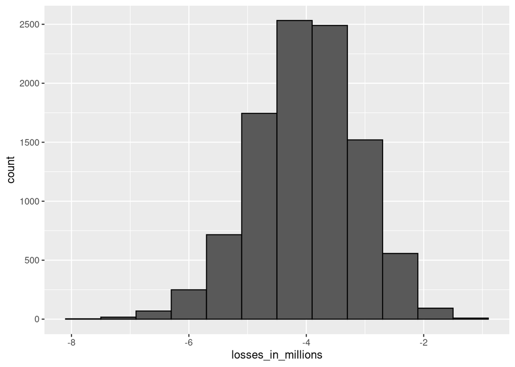

```r
data.frame(losses_in_millions = losses/10^6) %>%
    ggplot(aes(losses_in_millions)) +
    geom_histogram(binwidth = 0.6, col = "black")
```

```r
# Expected value and standard error of the sum of 1,000 loans
n*(p*loss_per_foreclosure + (1-p)*0)    # expected value
```

```
## [1] -4e+06
```

```r
sqrt(n)*abs(loss_per_foreclosure)*sqrt(p*(1-p))    # standard error
```

```
## [1] 885437.7
```

-We can calculate the amount x to add to each loan so that the expected value is 0 using the equation l*p + x*(1-p) = 0. Note that this equation is the definition of expected value given a loss per foreclosure with foreclosure probability p and profit x if there is no foreclosure (probability 1-p).

x = -l*p / (1 - p)

```r
x <- -loss_per_foreclosure*p/(1-p)
x
```

```
## [1] 4081.633
```

We should gain 4081.633$ by each loan. On a 180.000$ loan it means

```r
x/180000
```

```
## [1] 0.02267574
```

We want to calculate the value of x for which Pr(S<0) = 0.01. The expected value E[S] of the sum of n = 1000 loans given our definitions of x, l and p is:

```r
mu <- n * (loss_per_foreclosure*p + x*(1-p))
sigma <- abs(x-loss_per_foreclosure) * sqrt(n*p*(1-p))
```

Because we know the definition of a Z-score is Z = (x - mu) / sigma, we know that Pr(S<0) = Pr(Z < -mu/sigma). Thus, Pr(S < 0) = 0.01 equals:

x <- -l*((np - z*sqrt(np(1-p)))/(n(1-p)+z*sqrt(np(1-p))))

```r
# Calculating interest rate for 1% probability of losing money
l <- loss_per_foreclosure
z <- qnorm(0.01)
x <- -l*( n*p - z*sqrt(n*p*(1-p)))/ ( n*(1-p) + z*sqrt(n*p*(1-p)))
x/180000    # interest rate
```

```
## [1] 0.03471767
```

```r
loss_per_foreclosure*p + x*(1-p)    # expected value of the profit per loan
```

```
## [1] 2124.198
```

```r
n*(loss_per_foreclosure*p + x*(1-p)) # expected value of the profit over n loans
```

```
## [1] 2124198
```

```r
#  Monte Carlo simulation for 1% probability of losing money

B <- 100000
profit <- replicate(B, {
    draws <- sample( c(x, loss_per_foreclosure), n,
                        prob=c(1-p, p), replace = TRUE)
    sum(draws)
})
mean(profit)    # expected value of the profit over n loans
```

```
## [1] 2126219
```

```r
mean(profit<0)    # probability of losing money
```

```
## [1] 0.0125
```

## The Big Short

- The Central Limit Theorem states that the sum of independent draws of a random variable follows a normal distribution. However, when the draws are not independent, this assumption does not hold.
- If an event changes the probability of default for all borrowers, then the probability of the bank losing money changes.
- Monte Carlo simulations can be used to model the effects of unknown changes in the probability of default.

```r
# Expected value with higher default rate and interest rate
p <- .04
loss_per_foreclosure <- -200000
r <- 0.05
x <- r*180000
loss_per_foreclosure*p + x*(1-p)
```

```
## [1] 640
```

We can define our desired probability of losing money, z, as

Pr(S < 0) = Pr(Z < -(mu/sigma)) = Pr(Z < z)

if z = -(mu/sigma) then z = -(n*avg)/sqrt(n*sd) = - sqrt(n*avg)/sd

z <= - sqrt(n*avg)/sd

```r
# Calculating number of loans for desired probability of losing money
z <- qnorm(0.01)
l <- loss_per_foreclosure
n <- ceiling((z^2*(x-l)^2*p*(1-p))/(l*p + x*(1-p))^2)
n    # number of loans required
```

```
## [1] 22163
```

```r
n*(loss_per_foreclosure*p + x * (1-p))    # expected profit over n loans
```

```
## [1] 14184320
```

```r
# Monte Carlo simulation
B <- 10000
p <- 0.04
x <- 0.05 * 180000
profit <- replicate(B, {
    draws <- sample( c(x, loss_per_foreclosure), n,
                        prob=c(1-p, p), replace = TRUE)
    sum(draws)
})
mean(profit)
```

```
## [1] 14182962
```

## Exercises

1. Say you manage a bank that gives out 10,000 loans. The default rate is 0.03 and you lose $200,000 in each foreclosure. Create a random variable S that contains the earnings of your bank. Calculate the total amount of money lost in this scenario.

```r
# Assign the number of loans to the variable `n`
n <- 10000

# Assign the loss per foreclosure to the variable `loss_per_foreclosure`
loss_per_foreclosure <- -200000

# Assign the probability of default to the variable `p_default`
p_default <- 0.03

# Use the `set.seed` function to make sure your answer matches the expected result after random sampling
set.seed(1)

# Generate a vector called `defaults` that contains the default outcomes of `n` loans
defaults <- sample(c(0,1), n, replace = T, prob = c(1-p_default, p_default))

# Generate `S`, the total amount of money lost across all foreclosures. Print the value to the console.
S <- sum(defaults * loss_per_foreclosure)
S
```

```
## [1] -6.3e+07
```

2. Run a Monte Carlo simulation with 10,000 outcomes for S, the sum of losses over 10,000 loans. Make a histogram of the results.

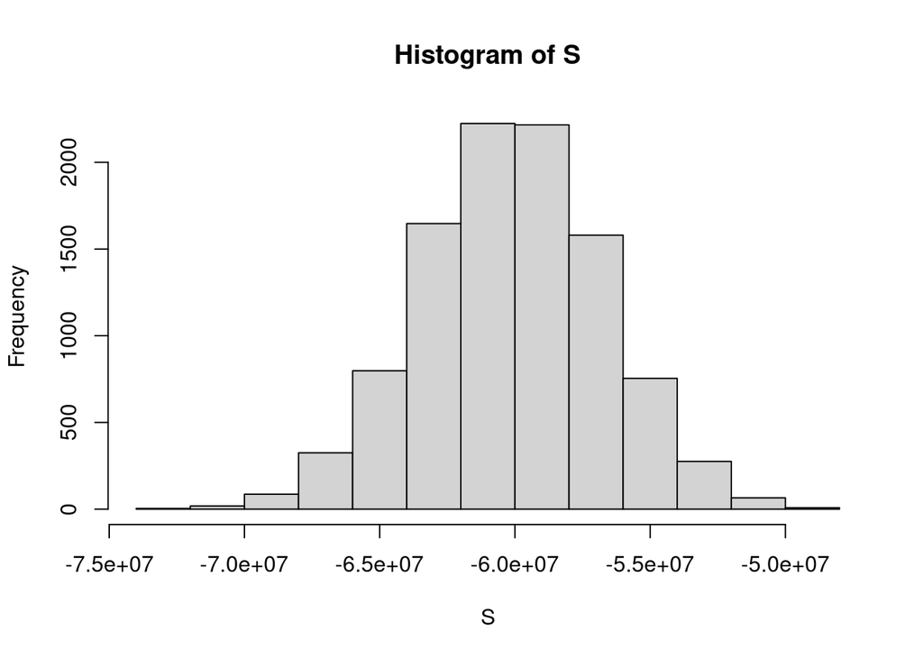

```r
# Assign the number of loans to the variable `n`
n <- 10000

# Assign the loss per foreclosure to the variable `loss_per_foreclosure`
loss_per_foreclosure <- -200000

# Assign the probability of default to the variable `p_default`
p_default <- 0.03

# Use the `set.seed` function to make sure your answer matches the expected result after random sampling
set.seed(1)

# The variable `B` specifies the number of times we want the simulation to run
B <- 10000

# Generate a list of summed losses 'S'. Replicate the code from the previous exercise over 'B' iterations to generate a list of summed losses for 'n' loans.  Ignore any warnings for now.
S <- replicate(B, {
  defaults <- sample(c(0,1), n, replace = T, prob = c(1-p_default, p_default))
  sum(defaults * loss_per_foreclosure)
})

hist(S)
```

3. What is the expected value of S, the sum of losses over 10,000 loans? For now, assume a bank makes no money if the loan is paid. What is the standard error?

```r
# Assign the number of loans to the variable `n`
n <- 10000

# Assign the loss per foreclosure to the variable `loss_per_foreclosure`
loss_per_foreclosure <- -200000

# Assign the probability of default to the variable `p_default`
p_default <- 0.03

# Calculate the expected loss due to default out of 10,000 loans
avg <- loss_per_foreclosure*p_default + 0*(1-p_default)
n*avg
```

```
## [1] -6e+07
```

```r
# Compute the standard error of the sum of 10,000 loans
sd <- abs(loss_per_foreclosure-0)*sqrt(p_default*(1-p_default))
sqrt(n) * sd
```

```
## [1] 3411744
```

4. So far, we’ve been assuming that we make no money when people pay their loans and we lose a lot of money when people default on their loans. Assume we give out loans for $180,000. How much money do we need to make when people pay their loans so that our net loss is $0? In other words, what interest rate do we need to charge in order to not lose money?

```r
# Assign the loss per foreclosure to the variable `loss_per_foreclosure`
loss_per_foreclosure <- -200000

# Assign the probability of default to the variable `p_default`
p_default <- 0.03

# Assign a variable `x` as the total amount necessary to have an expected outcome of $0
# l*p + x*(1-p) = 0
x = - loss_per_foreclosure*p_default/(1-p_default)

# Convert `x` to a rate, given that the loan amount is $180,000. Print this value to the console.
x <- x/180000
x
```

```
## [1] 0.03436426
```

5. With the interest rate calculated in the last example, we still lose money 50% of the time. What should the interest rate be so that the chance of losing money is 1 in 20? In math notation, what should the interest rate be so that Pr(S<0) = 0.05?

```r
# Assign the number of loans to the variable `n`
n <- 10000

# Assign the loss per foreclosure to the variable `loss_per_foreclosure`
loss_per_foreclosure <- -200000

# Assign the probability of default to the variable `p_default`
p_default <- 0.03

# Generate a variable `z` using the `qnorm` function
z <- qnorm(0.05)

# Generate a variable `x` using `z`, `p_default`, `loss_per_foreclosure`, and `n`
# x <- -l*((np - z*sqrt(np(1-p)))/(n(1-p)+z*sqrt(np(1-p))))
x <- -loss_per_foreclosure*( n*p_default - z*sqrt(n*p_default*(1-p_default)))/ ( n*(1-p_default) + z*sqrt(n*p_default*(1-p_default)))

# Convert `x` to an interest rate, given that the loan amount is $180,000. Print this value to the console.
x <- x/180000
x
```

```
## [1] 0.03768738
```

6. The bank wants to minimize the probability of losing money. Which of the following achieves their goal without making interest rates go up? Reduce default rate.